# EDA of Prosper Loan Data By Ramamohan Soma

I have chosen the Propser Loan data for this project to explore. There are 113,937 loans (rows) with 81 variables. Below are the names of all the variables.

```
##  [1] "ListingKey"
##  [2] "ListingNumber"
##  [3] "ListingCreationDate"
##  [4] "CreditGrade"
##  [5] "Term"
##  [6] "LoanStatus"
##  [7] "ClosedDate"
##  [8] "BorrowerAPR"
##  [9] "BorrowerRate"
## [10] "LenderYield"
## [11] "EstimatedEffectiveYield"
## [12] "EstimatedLoss"
## [13] "EstimatedReturn"
## [14] "ProsperRating (numeric)"
## [15] "ProsperRating (Alpha)"
```

[output cut: 66 more lines]

Below are the variables from the data I have chosen to analyse and more information on those variables.

```
##  [1] "Term"                         "LoanStatus"
##  [3] "BorrowerRate"                 "BorrowerState"
##  [5] "Occupation"                   "EmploymentStatus"
##  [7] "IsBorrowerHomeowner"          "CreditScoreRangeLower"
##  [9] "CreditScoreRangeUpper"        "CurrentDelinquencies"
## [11] "AmountDelinquent"             "IncomeRange"
## [13] "LoanCurrentDaysDelinquent"    "LoanOriginalAmount"
## [15] "LoanOriginationQuarter"       "MonthlyLoanPayment"
## [17] "LP_CustomerPayments"          "LP_CustomerPrincipalPayments"
## [19] "LP_InterestandFees"           "LP_NetPrincipalLoss"
## [21] "Year"
```

```
## 'data.frame':    113937 obs. of  21 variables:
##  $ Term                        : int  36 36 36 36 36 60 36 36 36 36 ...
##  $ LoanStatus                  : Factor w/ 12 levels "Cancelled","Chargedoff",..: 3 4 3 4 4 4 4 4 4 4 ...
##  $ BorrowerRate                : num  0.158 0.092 0.275 0.0974 0.2085 ...
##  $ BorrowerState               : Factor w/ 52 levels "","AK","AL","AR",..: 7 7 12 12 25 34 18 6 16 16 ...
##  $ Occupation                  : Factor w/ 68 levels "","Accountant/CPA",..: 37 43 37 52 21 43 50 29 24 24 ...
##  $ EmploymentStatus            : Factor w/ 9 levels "","Employed",..: 9 2 4 2 2 2 2 2 2 2 ...
##  $ IsBorrowerHomeowner         : Factor w/ 2 levels "False","True": 2 1 1 2 2 2 1 1 2 2 ...
##  $ CreditScoreRangeLower       : int  640 680 480 800 680 740 680 700 820 820 ...
##  $ CreditScoreRangeUpper       : int  659 699 499 819 699 759 699 719 839 839 ...
##  $ CurrentDelinquencies        : int  2 0 1 4 0 0 0 0 0 0 ...
##  $ AmountDelinquent            : num  472 0 NA 10056 0 ...
##  $ IncomeRange                 : Factor w/ 8 levels "$0","$1-24,999",..: 4 5 7 4 3 3 4 4 4 4 ...
##  $ LoanCurrentDaysDelinquent   : int  0 0 0 0 0 0 0 0 0 0 ...
##  $ LoanOriginalAmount          : int  9425 10000 3001 10000 15000 15000 3000 10000 10000 10000 ...
##  $ LoanOriginationQuarter      : Factor w/ 33 levels "Q1 2006","Q1 2007",..: 18 8 2 32 24 33 16 16 33 33 ...
##  $ MonthlyLoanPayment          : num  330 319 123 321 564 ...
##  $ LP_CustomerPayments         : num  11396 0 4187 5143 2820 ...
##  $ LP_CustomerPrincipalPayments: num  9425 0 3001 4091 1563 ...
##  $ LP_InterestandFees          : num  1971 0 1186 1052 1257 ...
##  $ LP_NetPrincipalLoss         : num  0 0 0 0 0 0 0 0 0 0 ...
##  $ Year                        : chr  "2007" "2014" "2007" "2012" ...
```

```
##  [1] "Cancelled"              "Chargedoff"
##  [3] "Completed"              "Current"
##  [5] "Defaulted"              "FinalPaymentInProgress"
##  [7] "Past Due (>120 days)"   "Past Due (1-15 days)"
##  [9] "Past Due (16-30 days)"  "Past Due (31-60 days)"
## [11] "Past Due (61-90 days)"  "Past Due (91-120 days)"
```

```
##  [1] ""   "AK" "AL" "AR" "AZ" "CA" "CO" "CT" "DC" "DE" "FL" "GA" "HI" "IA"
## [15] "ID" "IL" "IN" "KS" "KY" "LA" "MA" "MD" "ME" "MI" "MN" "MO" "MS" "MT"
## [29] "NC" "ND" "NE" "NH" "NJ" "NM" "NV" "NY" "OH" "OK" "OR" "PA" "RI" "SC"
## [43] "SD" "TN" "TX" "UT" "VA" "VT" "WA" "WI" "WV" "WY"
```

```
## [1] ""              "Employed"      "Full-time"     "Not available"
## [5] "Not employed"  "Other"         "Part-time"     "Retired"
## [9] "Self-employed"
```

```
## [1] "False" "True"
```

```
## [1] "$0"             "$1-24,999"      "$100,000+"      "$25,000-49,999"
## [5] "$50,000-74,999" "$75,000-99,999" "Not displayed"  "Not employed"
```

```
##  [1] "Q1 2006" "Q1 2007" "Q1 2008" "Q1 2010" "Q1 2011" "Q1 2012" "Q1 2013"
##  [8] "Q1 2014" "Q2 2006" "Q2 2007" "Q2 2008" "Q2 2009" "Q2 2010" "Q2 2011"
## [15] "Q2 2012" "Q2 2013" "Q3 2006" "Q3 2007" "Q3 2008" "Q3 2009" "Q3 2010"
## [22] "Q3 2011" "Q3 2012" "Q3 2013" "Q4 2005" "Q4 2006" "Q4 2007" "Q4 2008"
## [29] "Q4 2009" "Q4 2010" "Q4 2011" "Q4 2012" "Q4 2013"
```

# Univariate Plots Section

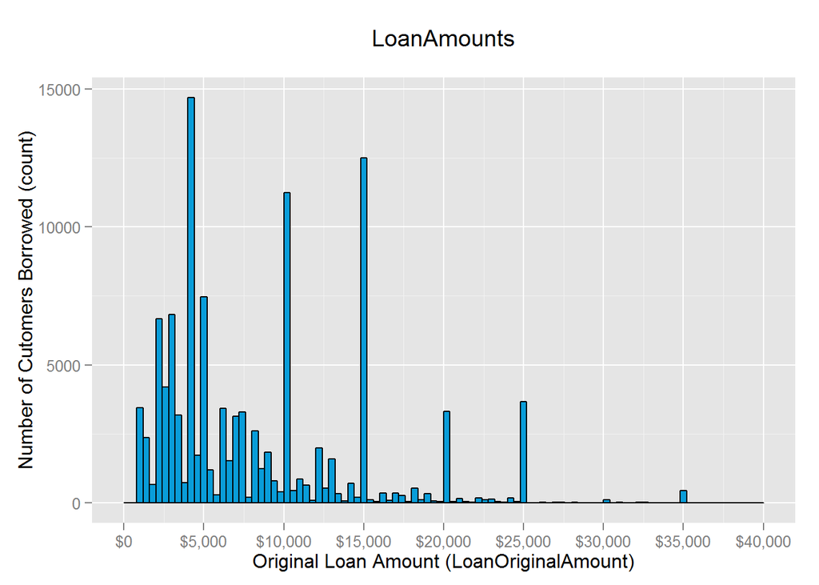

From the above plots it is evident that for most of the Loan Amonts the number of borrowers are below 7500. Also there is spike in users for the loan amounts around 4,000, 10,000, and 15,000 dollars. Below is the summary of LoanOriginalAmount. Mean in 8337 and Median is 6500.

```
##    Min. 1st Qu.  Median    Mean 3rd Qu.    Max.
##    1000    4000    6500    8337   12000   35000
```

```
## [1]  1000 35000
```

Let’s look at the terms of the loans that people were borrowing.

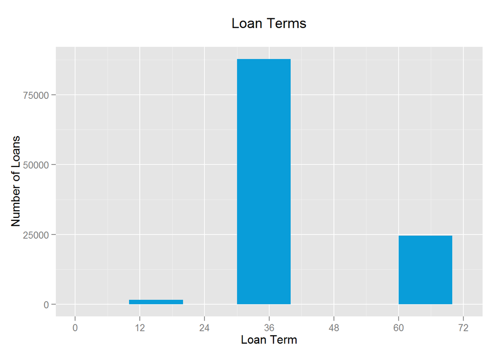

```
##
##    12    36    60
##  1614 87778 24545
```

I see that there are 3 types of Terms (12m, 36m, 60m) and 36months loans are famous(approximately 80% of the loans).

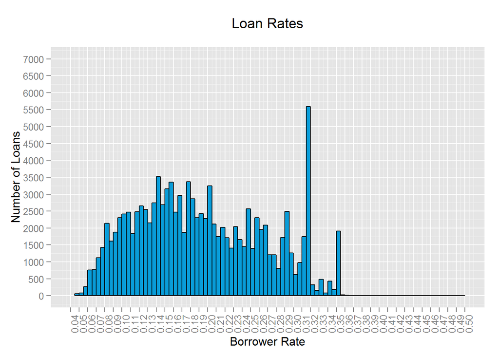

Summary and range of Borrower Rate.

```
##    Min. 1st Qu.  Median    Mean 3rd Qu.    Max.
##  0.0000  0.1340  0.1840  0.1928  0.2500  0.4975
```

```
## [1] 0.0000 0.4975
```

Below is the histogram of CreditScoreRangeUpper. Lets see how the number of loans varies based on upper range credit score.

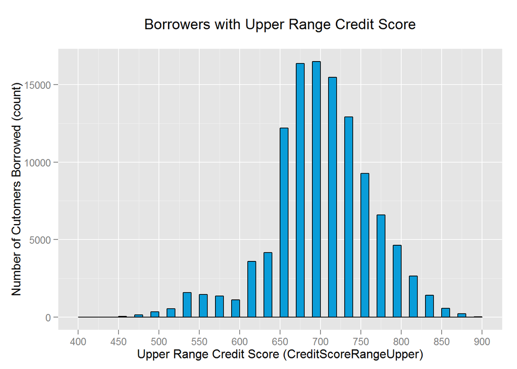

Borrowers with upper range credit score 650-800 have most of the loans.Borowers with upper range credit score of 679,699 have maximum number of loans. Median is 699. Below is the summary.

```
##    Min. 1st Qu.  Median    Mean 3rd Qu.    Max.    NA's
##    19.0   679.0   699.0   704.6   739.0   899.0     591
```

```
##
##    19   379   439   459   479   499   519   539   559   579   599   619
##   133     1     5    36   141   346   554  1593  1474  1357  1125  3602
##   639   659   679   699   719   739   759   779   799   819   839   859
##  4172 12199 16366 16492 15471 12923  9267  6606  4624  2644  1409   567
##   879   899
##   212    27
```

Let’s look at the status the of the Loans borrowed.

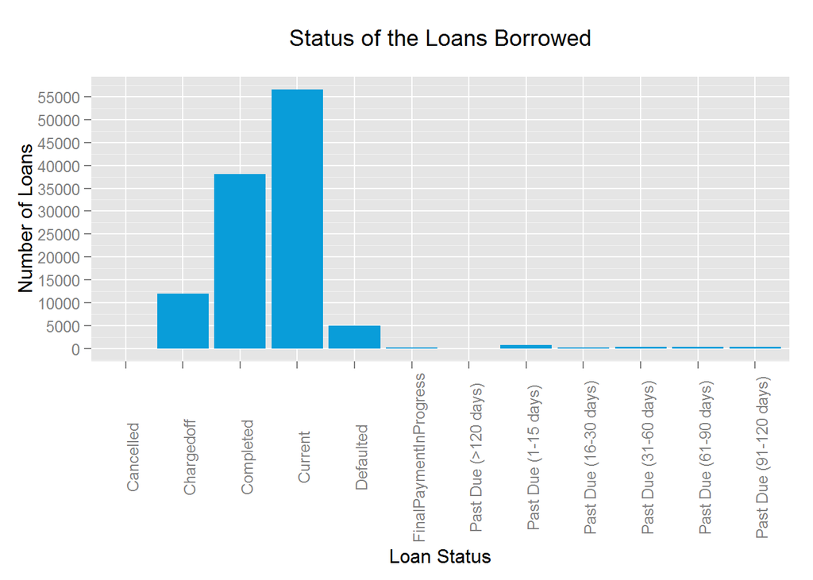

In the above plot most loans are either completed or current or chargedoff(~10%). There are approximately 5% defaulted loans.Below is info on each loan status.

```
##              Cancelled             Chargedoff              Completed
##                      5                  11992                  38074
##                Current              Defaulted FinalPaymentInProgress
##                  56576                   5018                    205
##   Past Due (>120 days)   Past Due (1-15 days)  Past Due (16-30 days)
##                     16                    806                    265
##  Past Due (31-60 days)  Past Due (61-90 days) Past Due (91-120 days)
##                    363                    313                    304
```

I would like to see howmany loans have been Delinquent. Below is the plot for current Delinquencies of the loans.

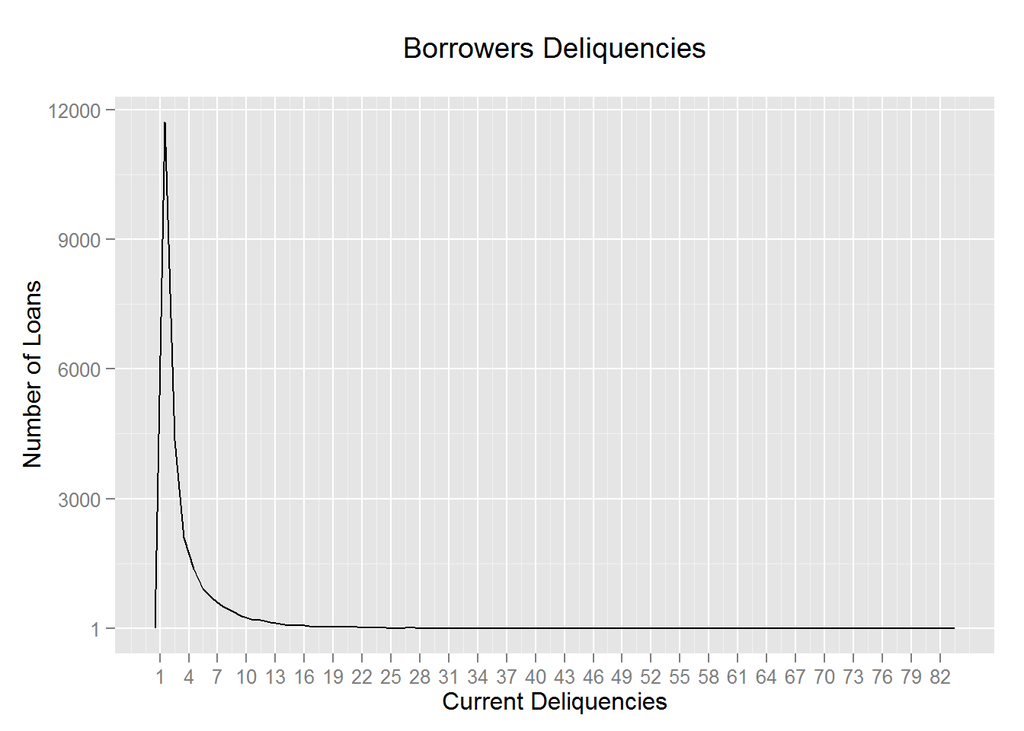

I see that ~12000 customers with 1 Deliquency. Interestingly numberof cusotmers decreased with the increase in Deliquency count. But still total number of Deliquencies is 67,044 which is high. Range is from 1 to 83. Not sure why so many Deliquencies even though loans were issued based on credit score.

Below is the Summary of CurrentDelinquencies with value > 0.

```
##    Min. 1st Qu.  Median    Mean 3rd Qu.    Max.
##   1.000   1.000   2.000   2.853   3.000  83.000
```

```
##
##     1     2     3     4     5     6     7     8     9    10    11    12
## 11716  4357  2098  1379   916   690   517   397   289   212   191   147
##    13    14    15    16    17    18    19    20    21    22    23    24
##   111    71    83    58    40    37    28    27    31    21     9    12
##    25    26    27    28    30    31    32    33    35    36    37    39
##     5     8    12     5     2     6     5     1     2     2     1     1
##    40    41    45    50    51    57    59    64    82    83
##     1     2     1     1     1     1     1     1     1     1
```

```
## [1] 67044
```

I want to look at the principal Loss of the loans to the investors. Below is the plot using the variable LP_NetPrincipalLoss which means the principal remains uncollected after any recoveries.

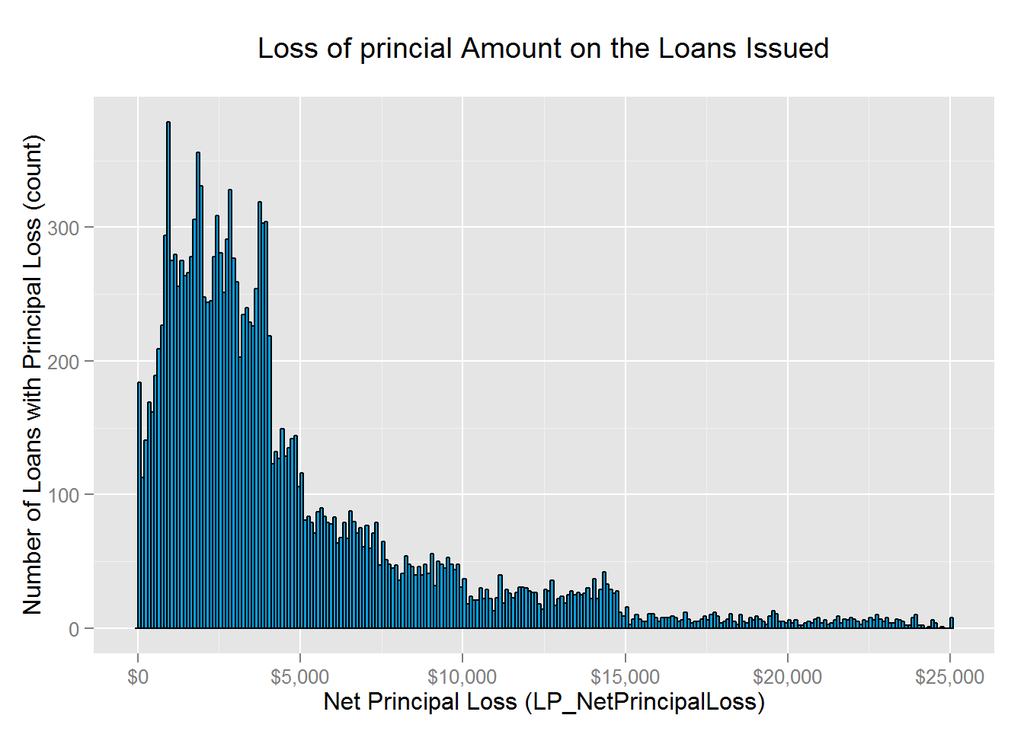

Above plot is made with the values of ‘LP_NetPrincipalLoss’ > 0. Most of the Principal Loss is under $5000. There are loans with Principal Loss between $5000 and $15000. NUmber of Loans with Principal Loss between $1500 to $25000 is much less compared to others.

Summary of ‘LP_NetPrincipalLoss’ > 0:

```
##    Min. 1st Qu.  Median    Mean 3rd Qu.    Max.
##       1    1764    3265    4664    5931   25000
```

I have observed that there are some loans with ‘LP_NetPrincipalLoss’ < 0 which means it’s a Principal Profit exculding Interest and Fees. Below is the plot.

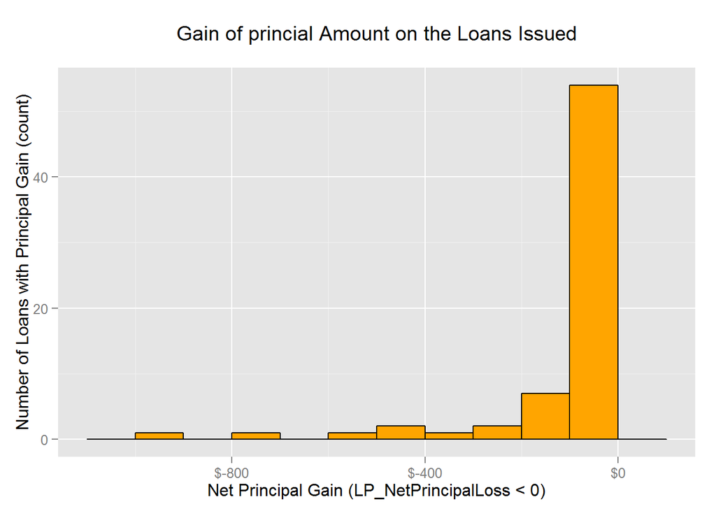

Summary of ‘LP_NetPrincipalLoss’ < 0:

```
##    Min. 1st Qu.  Median    Mean 3rd Qu.    Max.
## -954.60  -71.62  -23.82  -89.05  -10.51   -1.05
```

Now let’s look at the Numer of loans borrowed each Year.

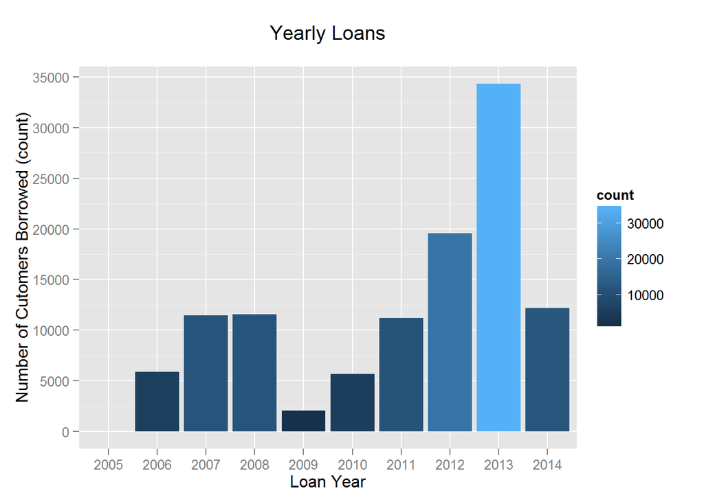

I have extracted the Year from the LoanOriginationQuarter and plotted the above histogram. Year 2013 have the maximum number of loans and 2009 have the lowest number of Loans. I need to investigate the reason for having so less number in 2009. Below is the number of Loans per year. I also see that in 2005 there were 22 loans. May be we can ignore that.

```
##
##  2005  2006  2007  2008  2009  2010  2011  2012  2013  2014
##    22  5906 11460 11552  2047  5652 11228 19553 34345 12172
```

# Univariate Analysis

### What is the structure of your dataset?

There are 113,937 loans in the Data set and 81 features. I have selected the below 17 features.

Term, LoanStatus, BorrowerState, EmploymentStatus, IsBorrowerHomeowner, LoanOriginationQuarter, BorrowerRate,CurrentDelinquencies,AmountDelinquent,IncomeRange,LoanCurrentDaysDelinquent,LoanOriginalAmount, MonthlyLoanPayment, LP_CustomerPayments, LP_CustomerPrincipalPayments, LP_InterestandFees, LP_NetPrincipalLoss

Minimum LoanAmount Borrowed is $1,000 and Maximum is $35,000. There are 3 Loan Terms (12 months, 36 months, 60 months). 36 Months loans are popular. Median Borrower rate is 18%(0.18). Employed and FullTime are the main Borrowers category who most took loans. Most of the Loans are either Current or Completed or ChargedOff. There are approximately 12,000 borrowers with 1 CurrentDeliquency and there total 67,044 current deliquencies which is high. There are 697 Current Deliquencies with ‘NA’. The Median LP_NetPrincipalLoss(The principal that remains uncollected after any recoveries) is $3265. Income Range of the most Borrowers is from $25,000 to $75,000.Year 2013 have the maximum number of loans and 2009 have the lowest number of Loans.

### What is/are the main feature(s) of interest in your dataset?

I am interested in many features from the data set but I have isolated to investigate the below features which tells about the Loan Amounts borrowed, Loan rates, Deliquencies etc.

BorrowerRate,CurrentDelinquencies,AmountDelinquent,IncomeRange,LoanCurrentDaysDelinquent,LoanOriginalAmount, MonthlyLoanPayment, Term, LoanStatus LP_NetPrincipalLoss, CreditScoreRangeUpper.

### What other features in the dataset do you think will help support your investigation into your feature(s) of interest?

I think Year of the loan would be helpful to see how many Current Deliquencies per year and how many Net Principal losses per year.

### Did you create any new variables from existing variables in the dataset?

Yes! I have created a new variable ‘year’ in which the loan was borrowed.

### Of the features you investigated, were there any unusual distributions? Did you perform any operations on the data to tidy, adjust, or change the form of the data? If so, why did you do this?

One thing I have observed is the number of lOans have decreased significantly in 2009. I need to investigate more on this and find the reason. I have extracted the year from LoanOriginationQuarter. Also for LP_NetPrincipalLoss, there are values which are > 0 (means loss) and < 0 (means gain). so in future plots I am planning to use LP_NetPrincipalLoss values with > 0.

# Bivariate Plots Section

First I want to explore the relationship between the LoanOriginalAmount and the CurrentDeliquencies.

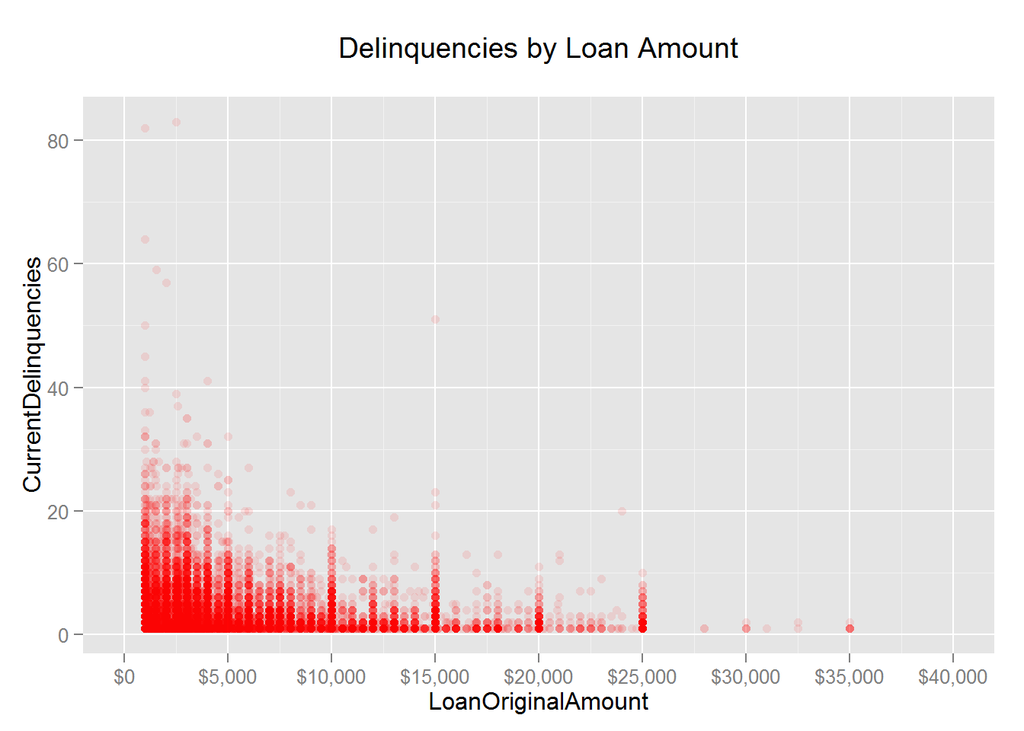

```
##
##  Pearson's product-moment correlation
##
## data:  LoanData$LoanOriginalAmount and LoanData$CurrentDelinquencies
## t = -58.8042, df = 113238, p-value < 2.2e-16
## alternative hypothesis: true correlation is not equal to 0
## 95 percent confidence interval:
##  -0.1777856 -0.1664820
## sample estimates:
##        cor
## -0.1721394
```

From the plot it seems LoanAmounts under $10,000 has many deliquencies. We can see straight lines in the plot for $10,000, $15,000, $20,000 and $25,000 which indicates there are deliquencies even for big amounts. Don’t see a good correlation between these two paramters. Correlation value is -0.1721394.

Let’s look at the CurrentDeliquencies versus Term Relationship to see which Term loans have more delinquencies.

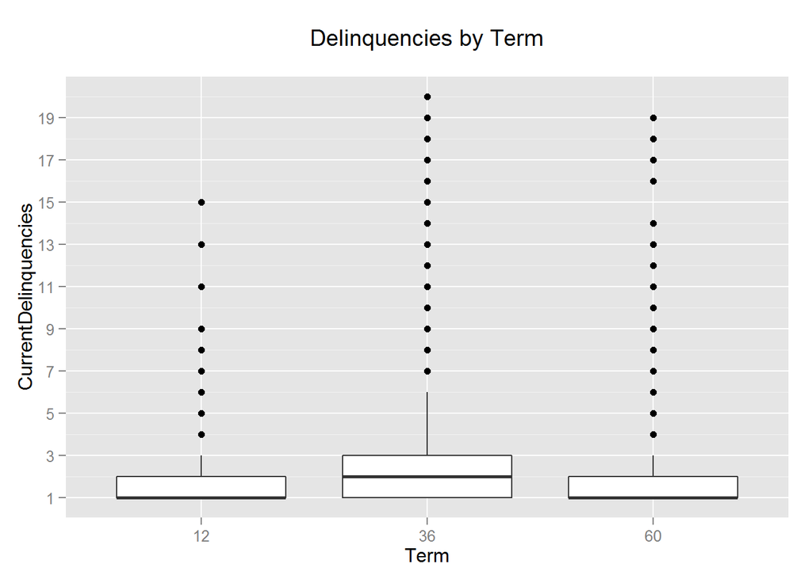

```
##
##  Pearson's product-moment correlation
##
## data:  dfTemp$Term and dfTemp$CurrentDelinquencies
## t = -15.34, df = 23496, p-value < 2.2e-16
## alternative hypothesis: true correlation is not equal to 0
## 95 percent confidence interval:
##  -0.11222152 -0.08690293
## sample estimates:
##         cor
## -0.09957834
```

In the above plot I have limited the y-axis scale to 20 to get a better picture of the Box Plot. Ptot depicts that Delinquencies are more for 36 months Term Loans than other Terms. Correlation Value is -0.0838 and the value without zero’s and ’NA’s is -0.0996. Below is the number of deliquencies for each Term.

```
## dfTemp$Term: 12
## [1] 708
## --------------------------------------------------------
## dfTemp$Term: 36
## [1] 60237
## --------------------------------------------------------
## dfTemp$Term: 60
## [1] 6099
```

Now I would like see how the number of Deliquencies varies by Income Range.

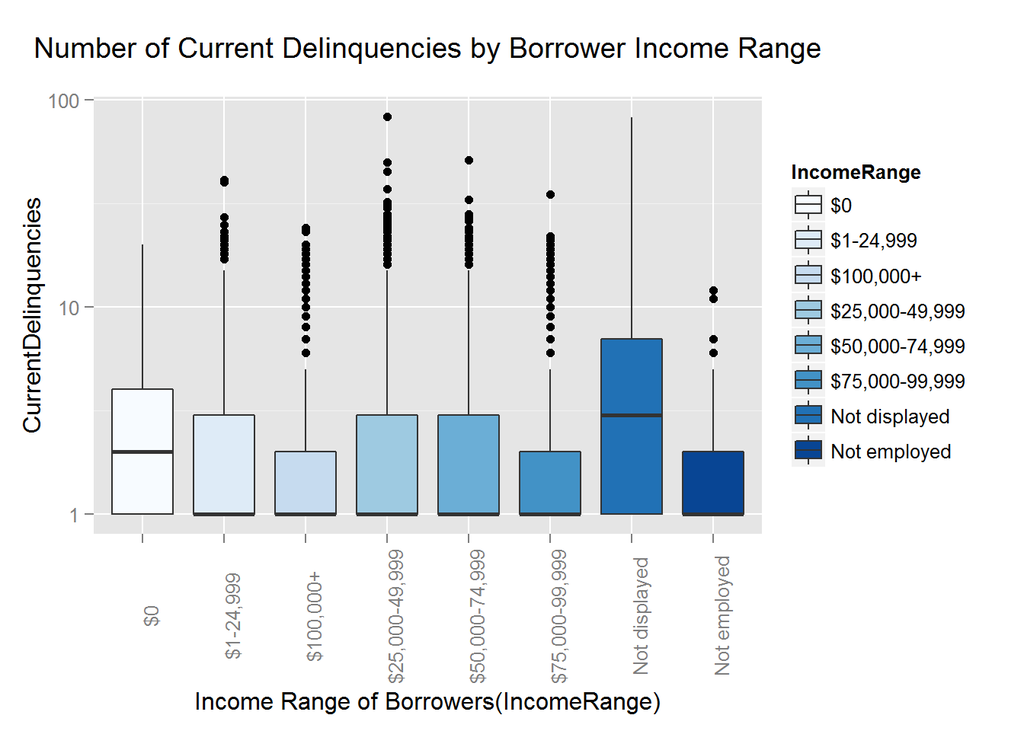

Below is the details of CurrentDeliquencies for each Income Range.

```
## dfTemp$IncomeRange: $0
##    Min. 1st Qu.  Median    Mean 3rd Qu.    Max.
##   1.000   1.000   2.000   3.392   4.000  20.000
## --------------------------------------------------------
## dfTemp$IncomeRange: $1-24,999
##    Min. 1st Qu.  Median    Mean 3rd Qu.    Max.
##   1.000   1.000   1.000   2.738   3.000  41.000
## --------------------------------------------------------
## dfTemp$IncomeRange: $100,000+
##    Min. 1st Qu.  Median    Mean 3rd Qu.    Max.
##   1.000   1.000   1.000   2.222   2.000  24.000
## --------------------------------------------------------
## dfTemp$IncomeRange: $25,000-49,999
##    Min. 1st Qu.  Median    Mean 3rd Qu.    Max.
##   1.000   1.000   1.000   2.582   3.000  83.000
## --------------------------------------------------------
## dfTemp$IncomeRange: $50,000-74,999
##    Min. 1st Qu.  Median    Mean 3rd Qu.    Max.
##   1.000   1.000   1.000   2.378   3.000  51.000
## --------------------------------------------------------
## dfTemp$IncomeRange: $75,000-99,999
##    Min. 1st Qu.  Median    Mean 3rd Qu.    Max.
##   1.000   1.000   1.000   2.264   2.000  35.000
## --------------------------------------------------------
## dfTemp$IncomeRange: Not displayed
##    Min. 1st Qu.  Median    Mean 3rd Qu.    Max.
##   1.000   1.000   3.000   5.098   7.000  82.000
## --------------------------------------------------------
## dfTemp$IncomeRange: Not employed
##    Min. 1st Qu.  Median    Mean 3rd Qu.    Max.
##   1.000   1.000   1.000   2.027   2.000  12.000
```

Meadian and Min Value of CurrentDeliquencies for Income Ranges $1-24,999, $25,000-49,999,$50,000-74,999, $75,000-99,999, $100,000+ and Not Employed are same and it’s 1. Median value for Borrowers with Income $0 is 2.Surprisingly for Borrowers whose Income Range is Not Displayed is 3 and Maximum is 82. Maximum for below Mid Range Income($25,000-49) is 83.

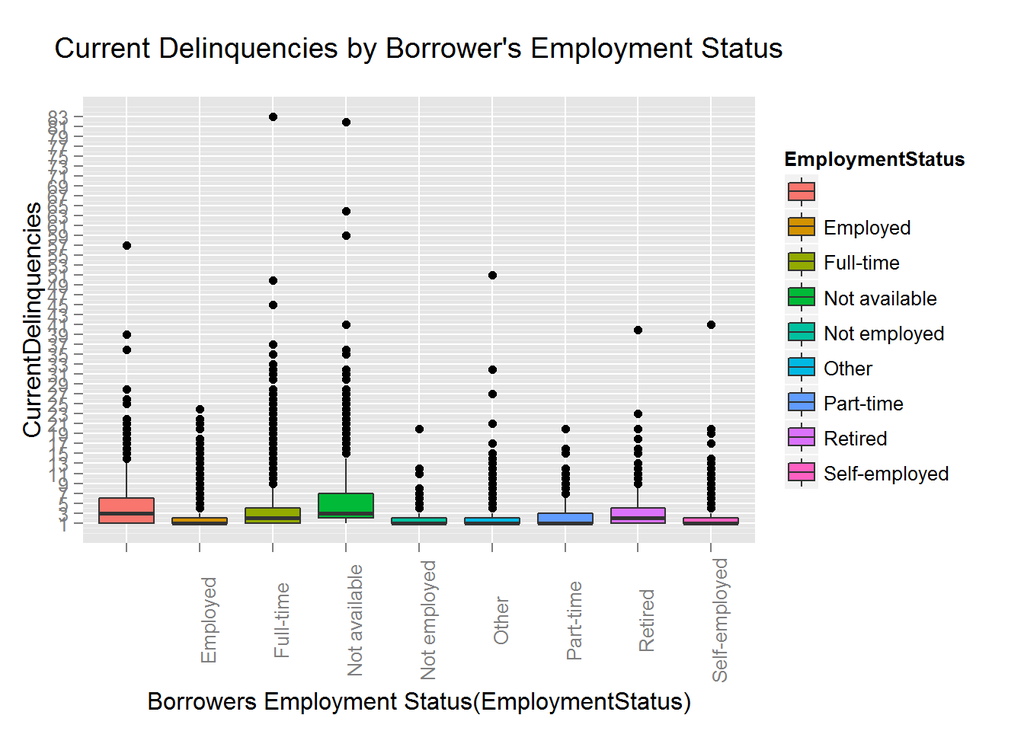

Below is the details of CurrentDelinquencies for each Employment Status.

```
## dfTemp$EmploymentStatus:
##    Min. 1st Qu.  Median    Mean 3rd Qu.    Max.
##   1.000   1.000   3.000   4.756   6.000  57.000
## --------------------------------------------------------
## dfTemp$EmploymentStatus: Employed
##    Min. 1st Qu.  Median    Mean 3rd Qu.    Max.
##    1.00    1.00    1.00    1.97    2.00   24.00
## --------------------------------------------------------
## dfTemp$EmploymentStatus: Full-time
##    Min. 1st Qu.  Median    Mean 3rd Qu.    Max.
##   1.000   1.000   2.000   3.178   4.000  83.000
## --------------------------------------------------------
## dfTemp$EmploymentStatus: Not available
##    Min. 1st Qu.  Median    Mean 3rd Qu.    Max.
##   1.000   2.000   3.000   5.244   7.000  82.000
## --------------------------------------------------------
## dfTemp$EmploymentStatus: Not employed
##    Min. 1st Qu.  Median    Mean 3rd Qu.    Max.
##   1.000   1.000   1.000   2.215   2.000  20.000
## --------------------------------------------------------
## dfTemp$EmploymentStatus: Other
##    Min. 1st Qu.  Median    Mean 3rd Qu.    Max.
##   1.000   1.000   1.000   2.394   2.000  51.000
## --------------------------------------------------------
## dfTemp$EmploymentStatus: Part-time
##    Min. 1st Qu.  Median    Mean 3rd Qu.    Max.
##   1.000   1.000   1.000   2.726   3.000  20.000
## --------------------------------------------------------
## dfTemp$EmploymentStatus: Retired
##    Min. 1st Qu.  Median    Mean 3rd Qu.    Max.
##   1.000   1.000   2.000   3.418   4.000  40.000
## --------------------------------------------------------
## dfTemp$EmploymentStatus: Self-employed
##    Min. 1st Qu.  Median    Mean 3rd Qu.    Max.
##   1.000   1.000   1.000   2.251   2.000  41.000
```

Full Time Employed Borrowers have a median of 2 and Maximum of 83. There is a group of Borrowers whose employment status is ‘Not Available’. Median for them is 3 and Maximum is 82 which is pretty high. There are many Borrowers whose Employment Status is blank and they have a median of 3 and Maximum of 57.

Now Lets see how the number of CurrentDelinquencies varies by Year.

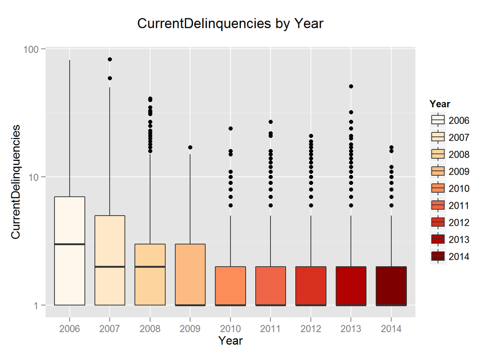

Below is the number of CurrentDelinquencies per year.

```
## dfTemp$Year: 2006
## [1] 13850
## --------------------------------------------------------
## dfTemp$Year: 2007
## [1] 17496
## --------------------------------------------------------
## dfTemp$Year: 2008
## [1] 8300
## --------------------------------------------------------
## dfTemp$Year: 2009
## [1] 536
## --------------------------------------------------------
## dfTemp$Year: 2010
## [1] 1643
## --------------------------------------------------------
## dfTemp$Year: 2011
## [1] 5112
## --------------------------------------------------------
## dfTemp$Year: 2012
## [1] 7876
## --------------------------------------------------------
## dfTemp$Year: 2013
## [1] 10103
## --------------------------------------------------------
## dfTemp$Year: 2014
## [1] 2128
```

Number of CurrentDelinquencies were high in 2006 and 2007. There’s a decrease in the count significantly in 2009 but again picked up in later years.

I want to see the relationship between CurrentDelinquencies and CreditScoreRangeUpper. Below is the plot.

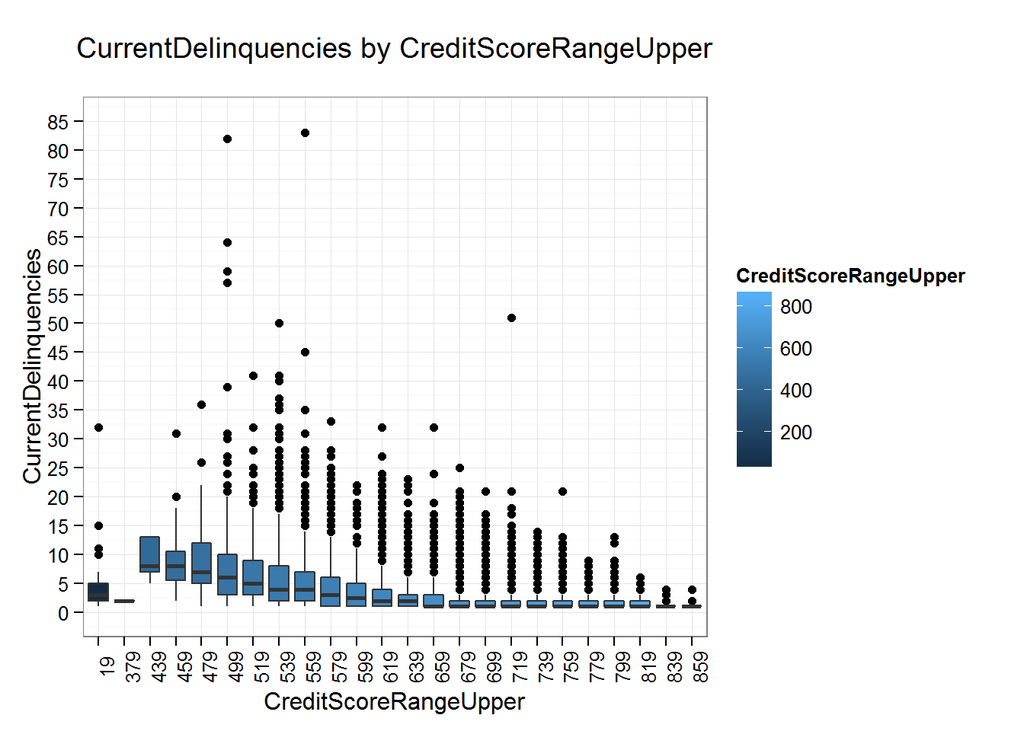

```
##
##  Pearson's product-moment correlation
##
## data:  dfTemp$CreditScoreRangeUpper and dfTemp$CurrentDelinquencies
## t = -61.7632, df = 23496, p-value < 2.2e-16
## alternative hypothesis: true correlation is not equal to 0
## 95 percent confidence interval:
##  -0.3846825 -0.3626818
## sample estimates:
##        cor
## -0.3737347
```

```
## dfTemp$CreditScoreRangeUpper: 19
##    Min. 1st Qu.  Median    Mean 3rd Qu.    Max.
##   1.000   2.000   3.000   3.969   5.000  32.000
## --------------------------------------------------------
## dfTemp$CreditScoreRangeUpper: 379
##    Min. 1st Qu.  Median    Mean 3rd Qu.    Max.
##       2       2       2       2       2       2
## --------------------------------------------------------
## dfTemp$CreditScoreRangeUpper: 439
##    Min. 1st Qu.  Median    Mean 3rd Qu.    Max.
##     5.0     7.0     8.0     9.2    13.0    13.0
## --------------------------------------------------------
## dfTemp$CreditScoreRangeUpper: 459
##    Min. 1st Qu.  Median    Mean 3rd Qu.    Max.
##   2.000   5.500   8.000   9.171  10.500  31.000
## --------------------------------------------------------
## dfTemp$CreditScoreRangeUpper: 479
##    Min. 1st Qu.  Median    Mean 3rd Qu.    Max.
##   1.000   5.000   7.000   8.652  12.000  36.000
## --------------------------------------------------------
## dfTemp$CreditScoreRangeUpper: 499
##    Min. 1st Qu.  Median    Mean 3rd Qu.    Max.
##   1.000   3.000   6.000   8.291  10.000  82.000
## --------------------------------------------------------
## dfTemp$CreditScoreRangeUpper: 519
##    Min. 1st Qu.  Median    Mean 3rd Qu.    Max.
##   1.000   3.000   5.000   6.577   9.000  41.000
## --------------------------------------------------------
## dfTemp$CreditScoreRangeUpper: 539
##    Min. 1st Qu.  Median    Mean 3rd Qu.    Max.
##   1.000   2.000   4.000   6.032   8.000  50.000
## --------------------------------------------------------
## dfTemp$CreditScoreRangeUpper: 559
##    Min. 1st Qu.  Median    Mean 3rd Qu.    Max.
##   1.000   2.000   4.000   5.496   7.000  83.000
## --------------------------------------------------------
## dfTemp$CreditScoreRangeUpper: 579
##    Min. 1st Qu.  Median    Mean 3rd Qu.    Max.
##   1.000   1.000   3.000   4.831   6.000  33.000
## --------------------------------------------------------
```

[output cut: 40 more lines]

```
## dfTemp$CreditScoreRangeUpper: 799
##    Min. 1st Qu.  Median    Mean 3rd Qu.    Max.
##   1.000   1.000   1.000   1.658   2.000  13.000
## --------------------------------------------------------
## dfTemp$CreditScoreRangeUpper: 819
##    Min. 1st Qu.  Median    Mean 3rd Qu.    Max.
##   1.000   1.000   1.000   1.471   2.000   6.000
## --------------------------------------------------------
## dfTemp$CreditScoreRangeUpper: 839
##    Min. 1st Qu.  Median    Mean 3rd Qu.    Max.
##   1.000   1.000   1.000   1.267   1.000   4.000
## --------------------------------------------------------
## dfTemp$CreditScoreRangeUpper: 859
##    Min. 1st Qu.  Median    Mean 3rd Qu.    Max.
##   1.000   1.000   1.000   1.444   1.000   4.000
```

In the above plot, the median of delinquencies is high at credit score of 439, 459 and dereased by increase in credit score upto 659 and stays a 1 after that. Borrowers with credit score of 659 has highest sum of deliquencies. The number of deliquencies decreased from 759.

Lets look at the relationship between LoanOriginalAmount and MonthlyLoanPayment.

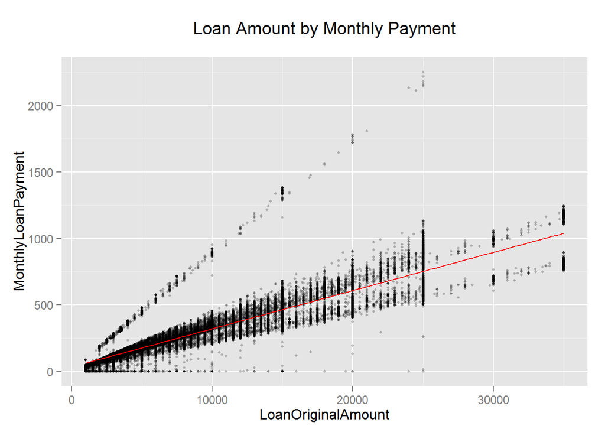

```
##
##  Pearson's product-moment correlation
##
## data:  LoanData$LoanOriginalAmount and LoanData$MonthlyLoanPayment
## t = 867.8179, df = 113935, p-value < 2.2e-16
## alternative hypothesis: true correlation is not equal to 0
## 95 percent confidence interval:
##  0.9312165 0.9327426
## sample estimates:
##       cor
## 0.9319837
```

There is a strong correlation between LoanOriginalAmount and MonthlyLoanPayment and the value is 0.932(rounded). It might be that as the Monthy Payment increases as Loan Amount increases. I see a line where there is steep increse in monthly payments as Loan Amount increases. It could be that BorrowerRate might also affect the relationship.

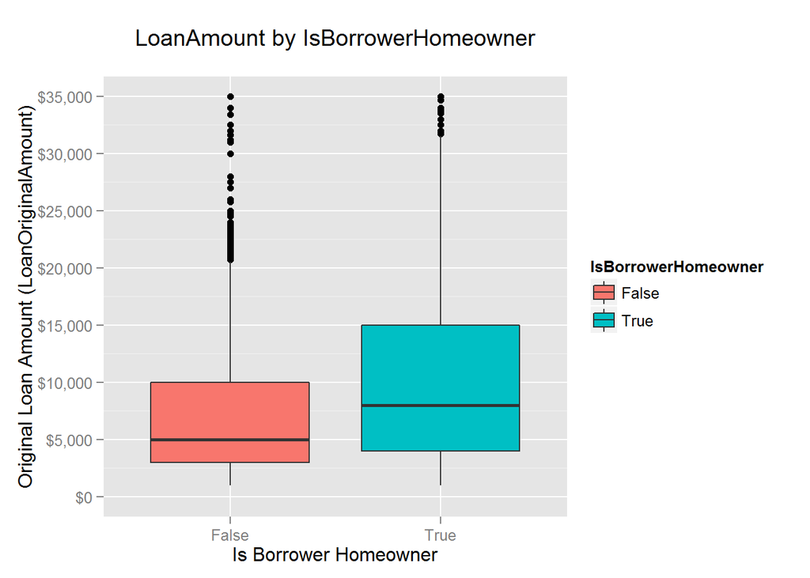

```
## LoanData$IsBorrowerHomeowner: False
##    Min. 1st Qu.  Median    Mean 3rd Qu.    Max.
##    1000    3000    5000    7034   10000   35000
## --------------------------------------------------------
## LoanData$IsBorrowerHomeowner: True
##    Min. 1st Qu.  Median    Mean 3rd Qu.    Max.
##    1000    4000    8000    9617   15000   35000
```

```
## False  True
## 56459 57478
```

In the above box plot, y-axis is limited to $35000 with breaks of $5000 to take a closer look.Then the statistics(Median,1st Quartuile,3rd Quartile) from ‘by’ command were matching the Box plots for Homeowners and Non Homeowners. Median, Mean and 3rd Quartile values are more for Homeowners which they are borrowing more money than non Homeowners. A little bit more than half of the borrowers are homeowners.

Below is the histogram of LoanOriginalAmount by EmploymentStatus.

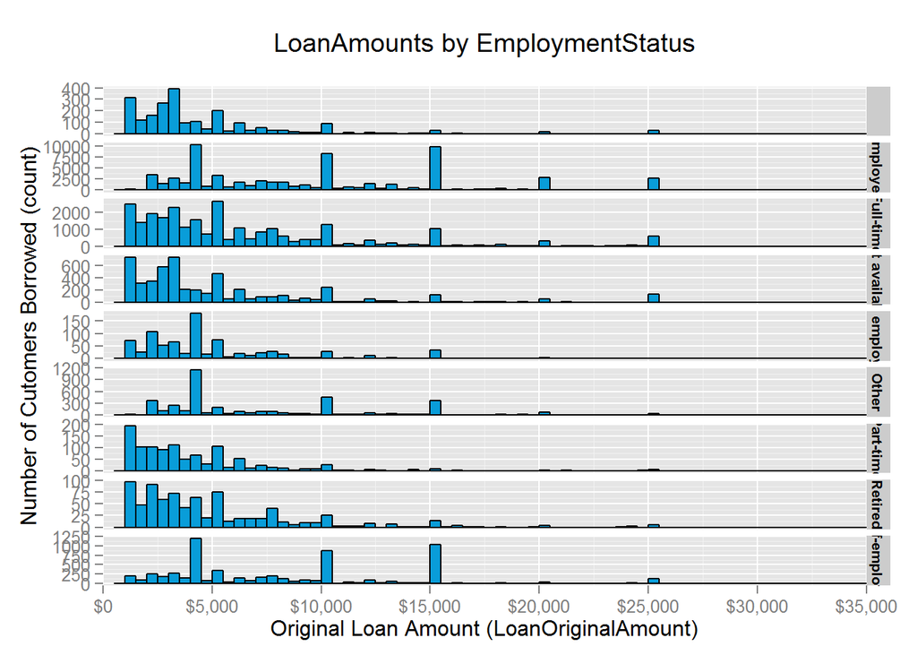

Now let’s look at the Income Range of the People who has borrowed loans and also if they are Homeowners or not.

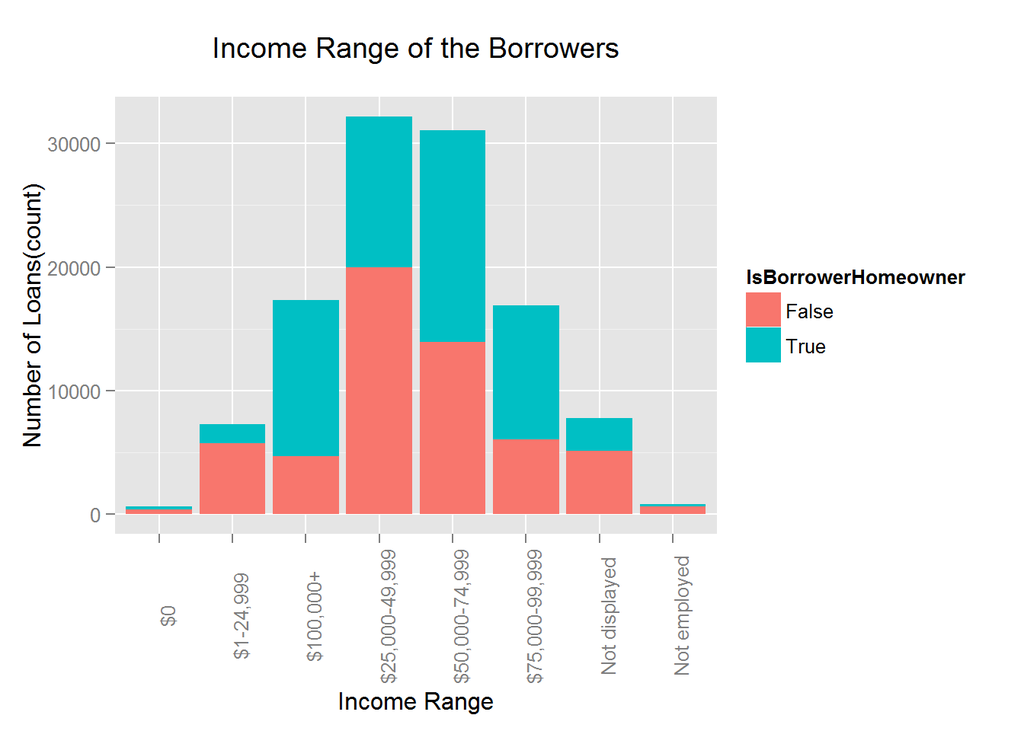

Income Range of the most Borrowers is in the middle ($25k to $75k) and many of them are not homeowners. Aslo with mostly 36 month loans as per the data.Surprisingly there are loans with zero Income Range of. Does that mean Borowers without income can get loans?

Below is the summary of Income range of the borrowers.

```
##             $0      $1-24,999      $100,000+ $25,000-49,999 $50,000-74,999
##            621           7274          17337          32192          31050
## $75,000-99,999  Not displayed   Not employed
##          16916           7741            806
```

In the UniVariate Plot on BorrowerRate, I saw a spike for the rate of 0.3177. I want to explore more on this. Below is the plot on BorrowerRate based on EmploymentStatus.

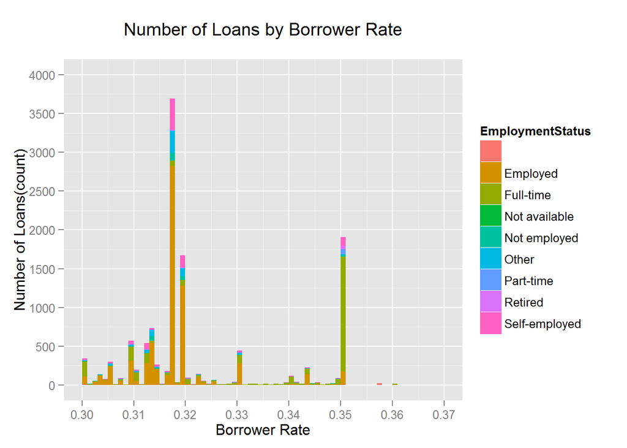

I see that Many Employed Borrowers got this rate. I see some ‘other’ and ‘SelfEmployed’ borrowers also have this rate.

Let’s see which income range borrowers has this rate. Below is the plot on BorrowerRate based on IncomeRange.

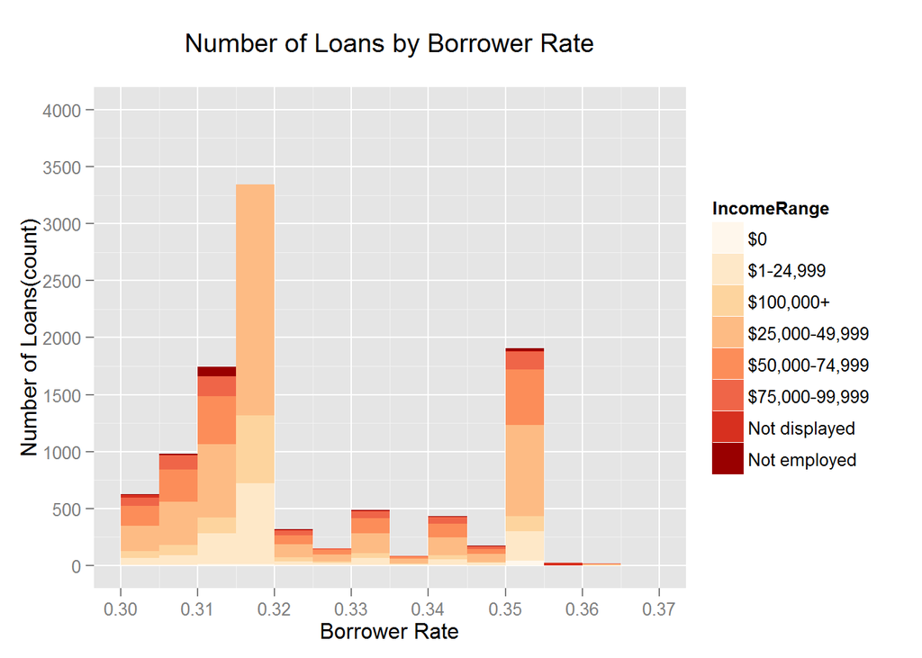

Let’s see the behaviour of LP_NetPrincipalLoss(The principal that remains uncollected after any recoveries.) against the LoanOriginalAmount.

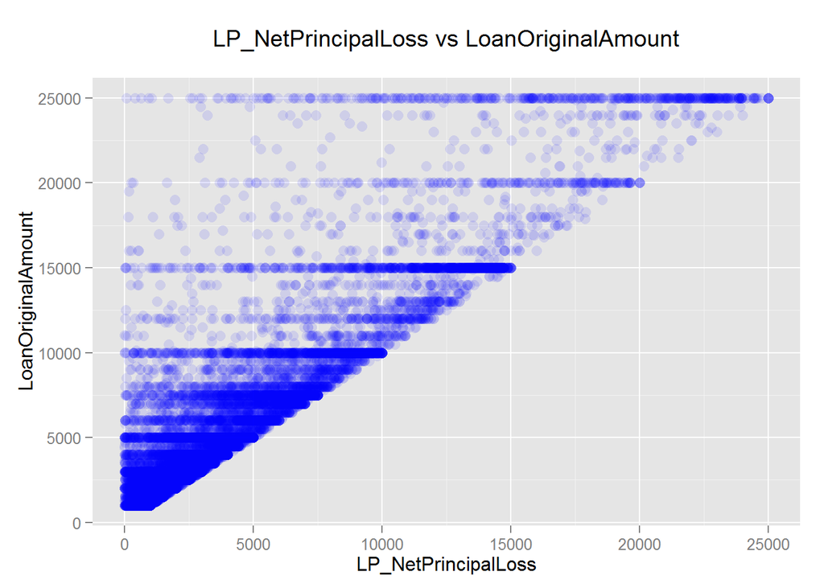

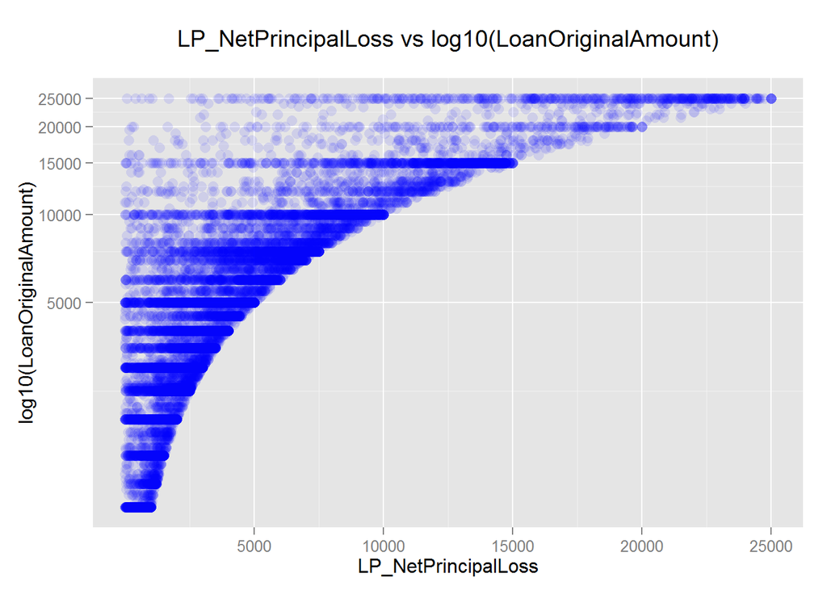

```
##
##  Pearson's product-moment correlation
##
## data:  LoanDataPL$LoanOriginalAmount and LoanDataPL$LP_NetPrincipalLoss
## t = 251.1217, df = 16644, p-value < 2.2e-16
## alternative hypothesis: true correlation is not equal to 0
## 95 percent confidence interval:
##  0.8862690 0.8926146
## sample estimates:
##       cor
## 0.8894846
```

I see a good correlation value of 0.889 between LP_NetPrincipalLoss and LoanOriginalAmount. LP_NetPrincipalLoss is high for Larger Loans.

Let’s see how the LP_NetPrincipalLoss varies each year.

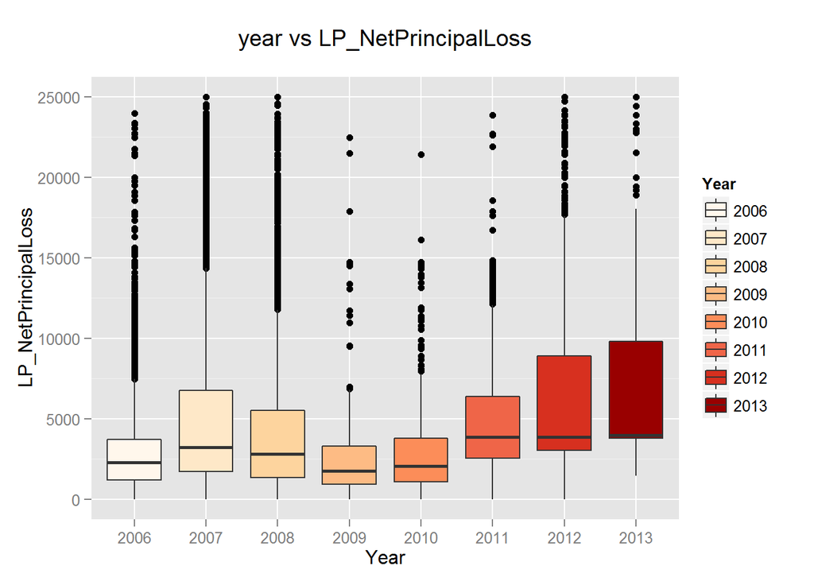

From the above plot I see that the median Net Principal Loss was high initially from 2006 to 2008 and it dropped in 2009. Then it gradually increased every year. Below is the summary of Net Principal Loss each year.

```
## LoanDataPL$Year: 2006
##     Min.  1st Qu.   Median     Mean  3rd Qu.     Max.
##     1.86  1201.00  2308.00  3150.00  3706.00 23970.00
## --------------------------------------------------------
## LoanDataPL$Year: 2007
##    Min. 1st Qu.  Median    Mean 3rd Qu.    Max.
##       1    1733    3240    5175    6779   25000
## --------------------------------------------------------
## LoanDataPL$Year: 2008
##     Min.  1st Qu.   Median     Mean  3rd Qu.     Max.
##     1.46  1353.00  2824.00  4348.00  5531.00 25000.00
## --------------------------------------------------------
## LoanDataPL$Year: 2009
##     Min.  1st Qu.   Median     Mean  3rd Qu.     Max.
##     7.94   934.70  1753.00  2731.00  3304.00 22470.00
## --------------------------------------------------------
## LoanDataPL$Year: 2010
##     Min.  1st Qu.   Median     Mean  3rd Qu.     Max.
##     1.56  1095.00  2059.00  2772.00  3791.00 21430.00
## --------------------------------------------------------
## LoanDataPL$Year: 2011
##     Min.  1st Qu.   Median     Mean  3rd Qu.     Max.
##     1.17  2573.00  3865.00  4715.00  6374.00 23870.00
## --------------------------------------------------------
## LoanDataPL$Year: 2012
##     Min.  1st Qu.   Median     Mean  3rd Qu.     Max.
##     2.03  3056.00  3879.00  6074.00  8892.00 25000.00
## --------------------------------------------------------
## LoanDataPL$Year: 2013
##    Min. 1st Qu.  Median    Mean 3rd Qu.    Max.
##    1453    3781    4000    7429    9815   25000
```

# Bivariate Analysis

### Talk about some of the relationships you observed in this part of the investigation. How did the feature(s) of interest vary with other features in the dataset?

- Relationship between LoanOrinalAmount and CurrentDeliquencies is not linear. Most of the current deliquencies are for Loan Amounts under $10,000. Ofcourse deliquencies do exists for higher Loan amounts from $15,000 to $35,000.
- Most of the Loans issued are 36 months Term and even the number of Deliquencies is high for these loans.
- Mid income range borowers have most deliquencies but surprisingly borrowers whose income range is not displayed also have a maximum of 82 deliquencies.
- Similary borrowers whose Employment Status is not displayed have signigicant deliquencies.
- There is a strong correlation between Monthly Loan Payment and the Loan Amount which should be and borrowers who are home owners have more Loans.
- Relationship between LoanOriginalAmount and LP_NetPrincipalLoss is also very strong.
- Net Principal Loss was high initially from 2006 to 2008, it dropped in 2009 and increased from 2010 to 2013.

### Did you observe any interesting relationships between the other features (not the main feature(s) of interest)?

Yes! I did observe some interesting relationship when I plotted the box plot between Year of the Loan originated vs CurrentDeliquencies, NetPrincipalLoss. There was sudden drop of Delinquencies and Net Principal Loss in the year 2009. On more investigation I found that in 2009 there was a relaunch of prosper and implemented stricter guide lines which caused the default rate significantly reduced.

### What was the strongest relationship you found?

The stronges relationships I found was between LoanoriginalAmount and MonthlyPayment, LoanOriginalAmount and LP_NetPrincipalLoss.

# Multivariate Plots Section

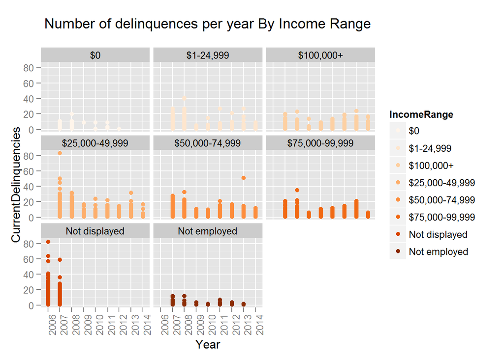

```
## dfTemp$Year: 2006
## [1] 13850
## --------------------------------------------------------
## dfTemp$Year: 2007
## [1] 17496
## --------------------------------------------------------
## dfTemp$Year: 2008
## [1] 8300
## --------------------------------------------------------
## dfTemp$Year: 2009
## [1] 536
## --------------------------------------------------------
## dfTemp$Year: 2010
## [1] 1643
## --------------------------------------------------------
## dfTemp$Year: 2011
## [1] 5112
## --------------------------------------------------------
## dfTemp$Year: 2012
## [1] 7876
## --------------------------------------------------------
## dfTemp$Year: 2013
## [1] 10103
## --------------------------------------------------------
## dfTemp$Year: 2014
## [1] 2128
```

```
## dfTemp$IncomeRange: $0
## [1] 329
## --------------------------------------------------------
## dfTemp$IncomeRange: $1-24,999
## [1] 4025
## --------------------------------------------------------
## dfTemp$IncomeRange: $100,000+
## [1] 5450
## --------------------------------------------------------
## dfTemp$IncomeRange: $25,000-49,999
## [1] 17898
## --------------------------------------------------------
## dfTemp$IncomeRange: $50,000-74,999
## [1] 13838
## --------------------------------------------------------
## dfTemp$IncomeRange: $75,000-99,999
## [1] 6652
## --------------------------------------------------------
## dfTemp$IncomeRange: Not displayed
## [1] 18548
## --------------------------------------------------------
## dfTemp$IncomeRange: Not employed
## [1] 304
```

From the plot we can that in 2006 all of the deliquencies were from the borrowers with income range “Not displayed”. Also there is a drop of number of deliquencies in 2009. Now let’s see the same based on Home owner type.

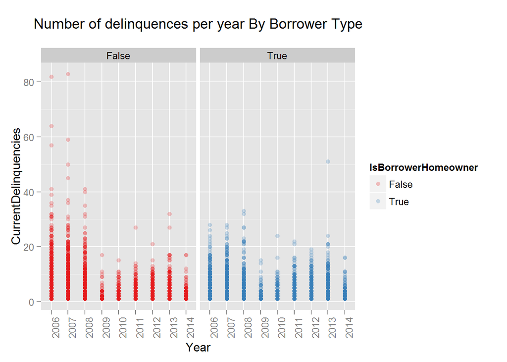

```
## dfTemp$IsBorrowerHomeowner: False
## [1] 39226
## --------------------------------------------------------
## dfTemp$IsBorrowerHomeowner: True
## [1] 27818
```

Here in the above plot we can see that Non Home owner borrowers deliquencies are bit more than Home owner borrowers deliquencies in the years 2006 - 2008.

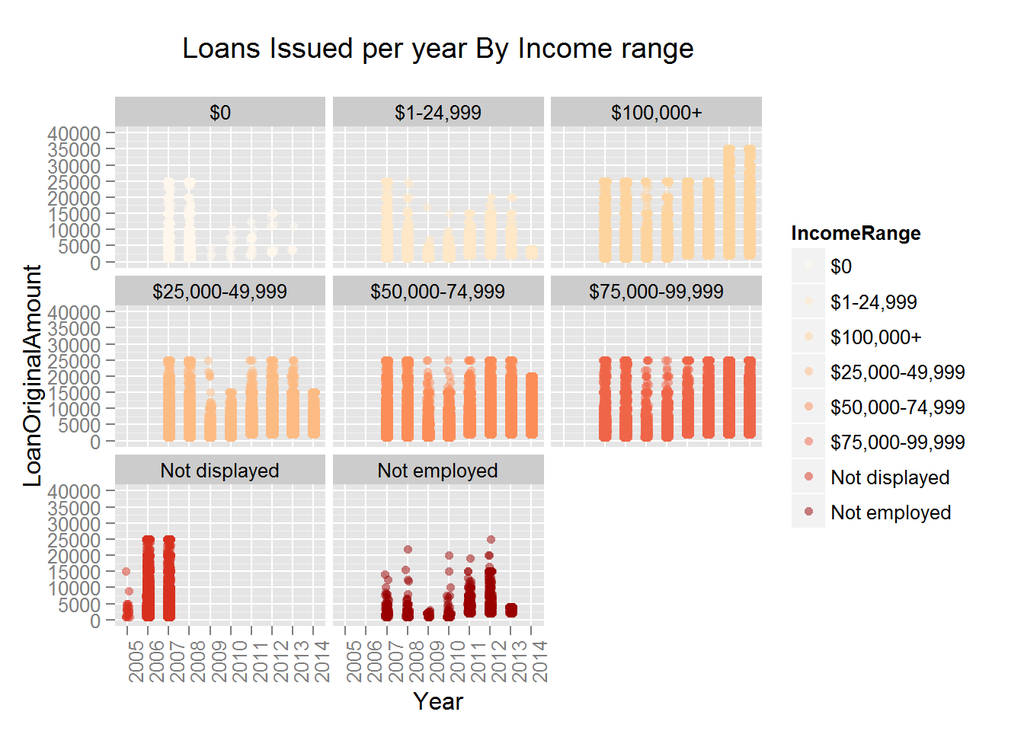

Surprisingly all the loans from 2006 were of the Borrowers whose income range is “Not displayed”. In the later years we can see a mix of borrowers with differnt Income ranges. In 2013 and 2014 there are many borrowers with income range above $100,000.

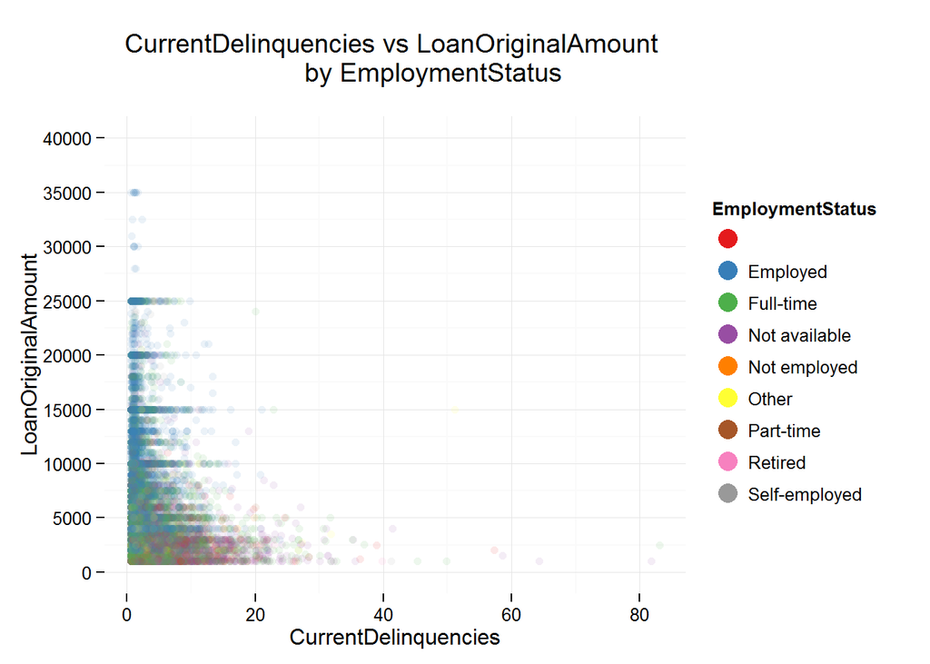

```
## dfTemp$EmploymentStatus:
## [1] 4261
## --------------------------------------------------------
## dfTemp$EmploymentStatus: Employed
## [1] 21215
## --------------------------------------------------------
## dfTemp$EmploymentStatus: Full-time
## [1] 21790
## --------------------------------------------------------
## dfTemp$EmploymentStatus: Not available
## [1] 14201
## --------------------------------------------------------
## dfTemp$EmploymentStatus: Not employed
## [1] 350
## --------------------------------------------------------
## dfTemp$EmploymentStatus: Other
## [1] 1793
## --------------------------------------------------------
## dfTemp$EmploymentStatus: Part-time
## [1] 537
## --------------------------------------------------------
## dfTemp$EmploymentStatus: Retired
## [1] 810
## --------------------------------------------------------
## dfTemp$EmploymentStatus: Self-employed
## [1] 2087
```

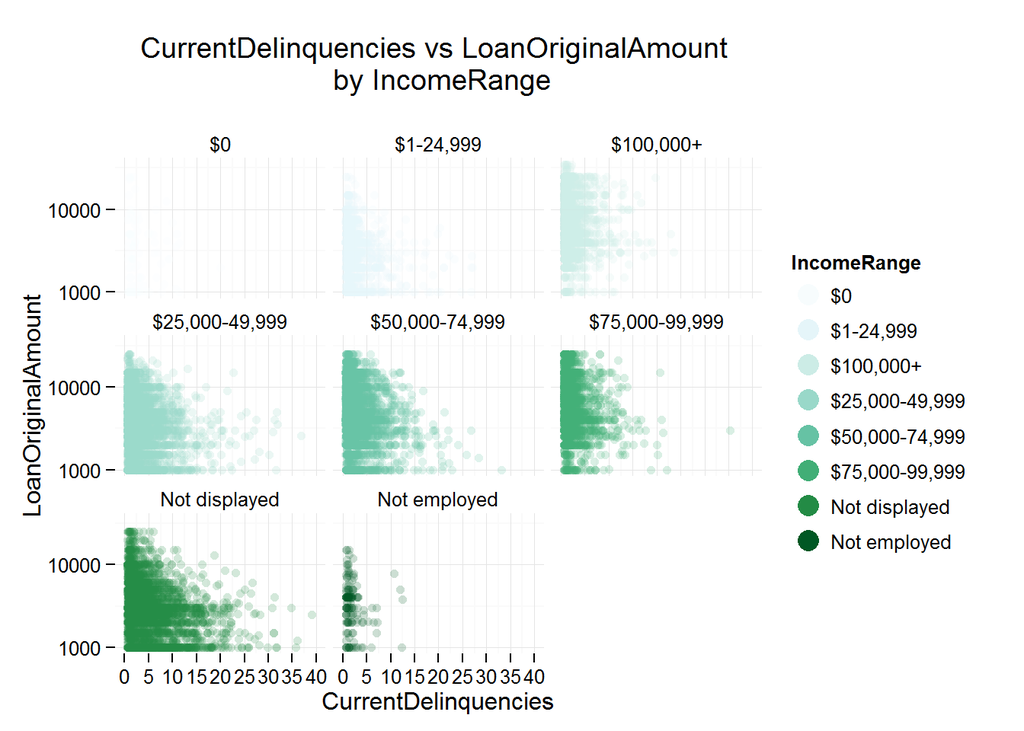

In the above plot, most of the borrowers whose Income Range is ‘Not displayed’ have deliquencies with Loan Amounts below $10,000. Deliquencies with high Loan Amounts are from borrowers with Income Range $100,000+.

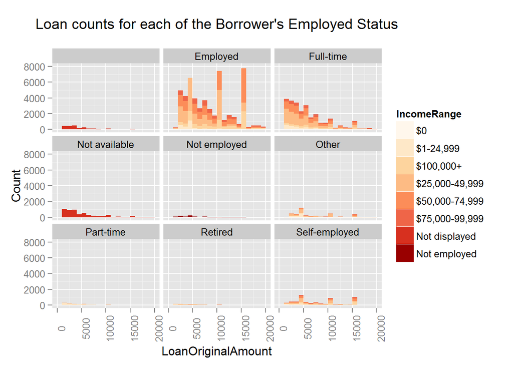

Here in the above plot we can see Employed and Full-time borrowers with income ranges from $1-$24,999 to $100,000+ are issued more Loans. Part-time and Retired borrowers are issued very few number of loans.

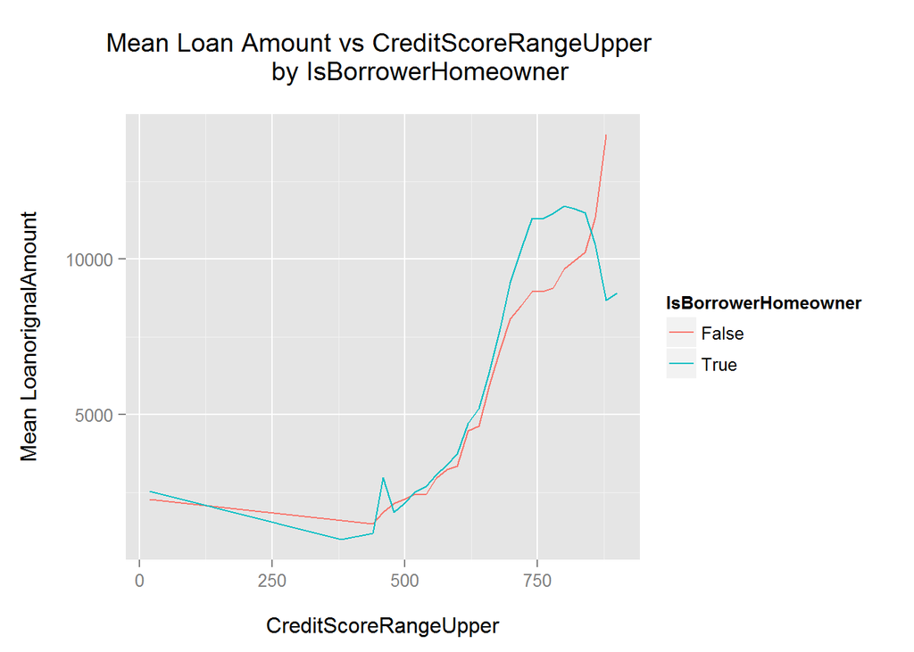

In the above plot Mean Loan Amout increases as Credit Score increases for Non Home owners but for Home owners there is a fall in the Mean Loan Amounts for the credit scores more than 800.